# Homework 5

**Due: 2022-3-3, 10:30am (before the class)**

We will use the [palmerpenguins](https://cran.r-project.org/web/packages/palmerpenguins/readme/README.html), which were collected and made available by Dr. Kristen Gorman and the Palmer Station, Antarctica LTER, a member of the Long Term Ecological Research Network.

The dataset contains data for 344 penguins of 3 different species (Adelie, Chinstrap and Gentoo). The dataset contains 8 variables, but we focus only on the flipper length and the species for this article.

You can use the following commands to load penguins data in R, and check the information of dataset.

```r
# install.packages("palmerpenguins")
library(palmerpenguins)
data(penguins, package="palmerpenguins")
attach(penguins)
head(penguins)
```

```
## # A tibble: 6 x 8
##   species island bill_length_mm bill_depth_mm flipper_length_~ body_mass_g sex
##   <fct>   <fct>           <dbl>         <dbl>            <int>       <int> <fct>
## 1 Adelie  Torge~           39.1          18.7              181        3750 male
## 2 Adelie  Torge~           39.5          17.4              186        3800 fema~
## 3 Adelie  Torge~           40.3          18                195        3250 fema~
## 4 Adelie  Torge~           NA            NA                 NA          NA <NA>
## 5 Adelie  Torge~           36.7          19.3              193        3450 fema~
## 6 Adelie  Torge~           39.3          20.6              190        3650 male
## # ... with 1 more variable: year <int>
```

```r
table(penguins$species)
```

```
##
##    Adelie Chinstrap    Gentoo
##       152        68       124
```

You can use the the following commands to roughly check the flipper length for different species.

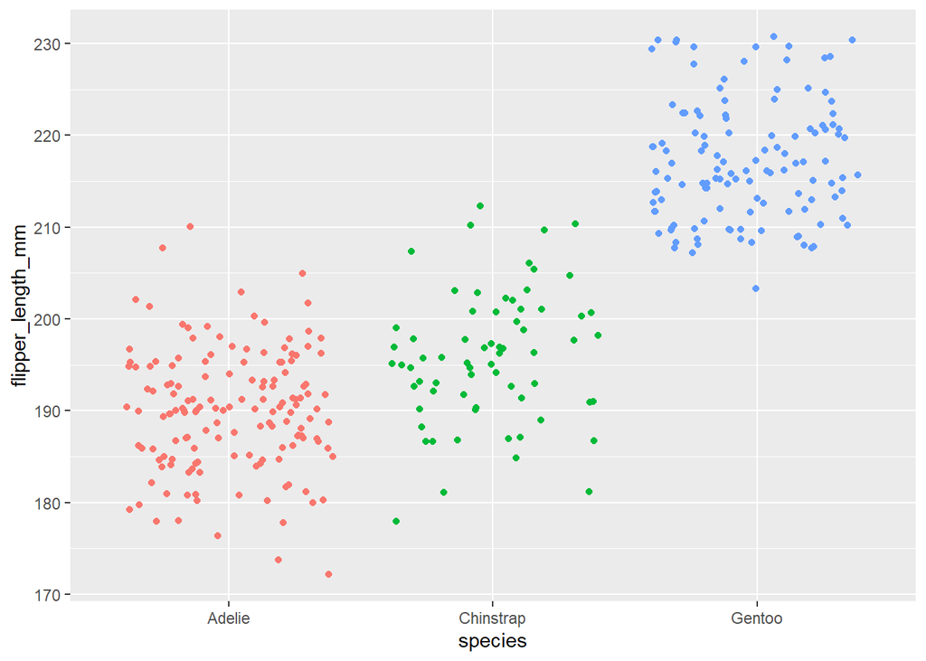

```r
library(ggplot2)
ggplot(penguins) +
  aes(x = species, y = flipper_length_mm, color = species) +
  geom_jitter() +
  theme(legend.position = "none")
```

### One-Way ANOVA

We are interested in the mean differences between species of flipper length.

1. (10%) Please calculate the mean and standard deviation of `flipper_length_mm` for each `species`.
2. (20%) Please apply one-way ANOVA to test the mean differences between species of flipper length and interpret the output.
3. (10%) Use the `TukeyHSD()` function to obtain all pairwise differences between species means and interpret the output.
4. (10%)Try to use regression analysis to test the association between species and flipper length.

### One-Way ANCOVA

We want to know whether or not the species has an association with flipper length accounting for the body mass.

The flipper length (`flipper_length_mm`) is the dependent variable. The species (`species`) is the independent variable. The body mass (`body_mass_g`) is included as a covariate.

5. (20%) Please apply one-way ANCOVA to test the mean differences between species of flipper length with controlling for the body mass.
6. (15%) Please interpret the output of Question 5.
7. (15%) Please use regression analysis to test the association between species and flipper length including the body mass as a covariate.